# Legend 图例

hou

2018/9/21

## Plot

基本绘图函数通过`legend()`函数添加图例。

函数中有一些必须的参数：

- 位置

  位置可以通过两种方式设置：
  1. 通过设置x，y坐标
  2. 通过keyword设置：

     top: 上

     topleft: 左上

     bottom: 下

     bottomright: 右下

     以及其他组合
- 图例名字

  参数`legend`
- 各名称对应的图案：
  - fill：填充颜色
  - pch：散点形状
  - lty：线条类型

  参数`fill`, `pch`和`lty`是用来区分不同的图例， 其中`fill`主要用于条形图中， `pch`和`lty`则用于散点图和折线图。

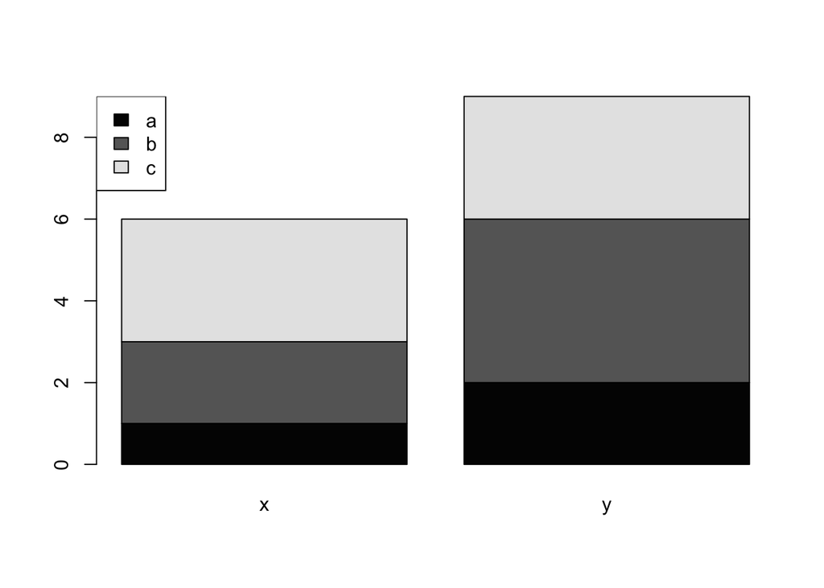

```r
x<-c(1,2,3)
y<-c(2,4,3)
t<-cbind(x,y)
barplot(t, col = c('gray1', 'gray40','gray90'))
legend("topleft", legend = c('a','b','c'), fill = c('gray1', 'gray40','gray90'))
```

### 2.1 其他参数

- 字体大小: `cex`
- 图例与文字的水平间距: `x.intersp`

如果觉得图例和文字之间的空间太大，可以令 `x.intersp`为负数

- 图例之间的垂直间距：`y.intersp`
- 图例边框: `bty = 'o'`显示边框， `bty = 'n'`不显示边框
- 设置图例水平放置: `horiz = T`
- 设置图例的列数(仅适用于图例垂直放置): `ncol`

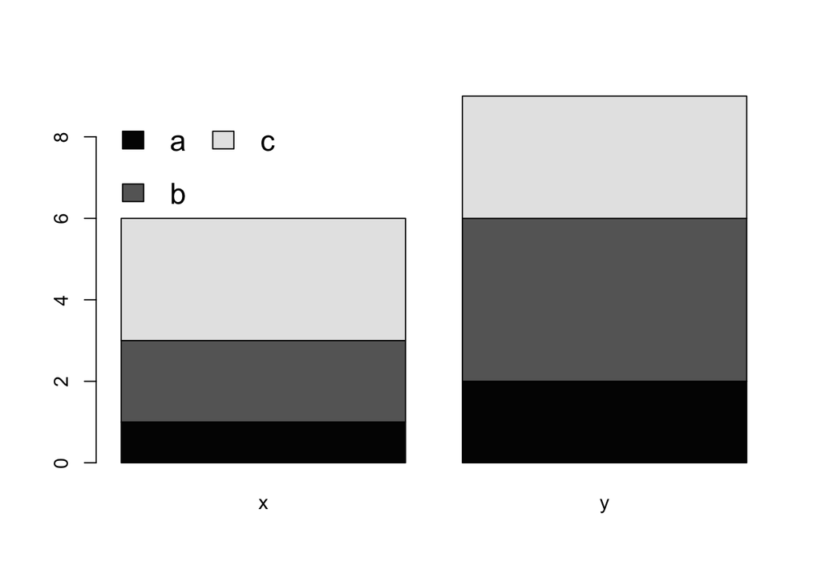

```r
x<-c(1,2,3)
y<-c(2,4,3)
t<-cbind(x,y)
barplot(t, col = c('gray1', 'gray40','gray90'))
legend("topleft", legend = c('a','b','c'), fill = c('gray1', 'gray40','gray90'), x.intersp = 1, y.intersp = 1.5, bty = 'n', cex = 1.5, ncol = 2)
```

## ggplot2

ggplot在画图时会自动生成图例，所以我们直接对图例进行修改。

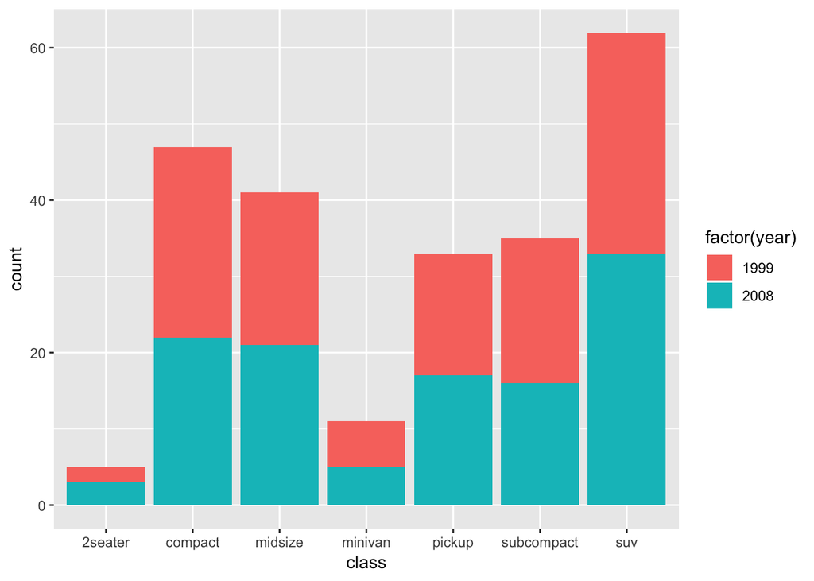

```r
library(ggplot2)
p <- ggplot(mpg, aes(x=class, fill=factor(year)))
p + geom_bar()
```

### 2.1 隐藏图例：

- 方法1：`guides(fill = FALSE)`隐藏由fill产生的图例（如上图），同理可以隐藏由color、shape产生的图例。
- 方法2：增加图层的时候把参数 `show.legend` 设为 `FALSE`，隐藏某图层的图例。
- 方法3：用 `theme(legend.position = 'none')` 来隐藏全局图例。

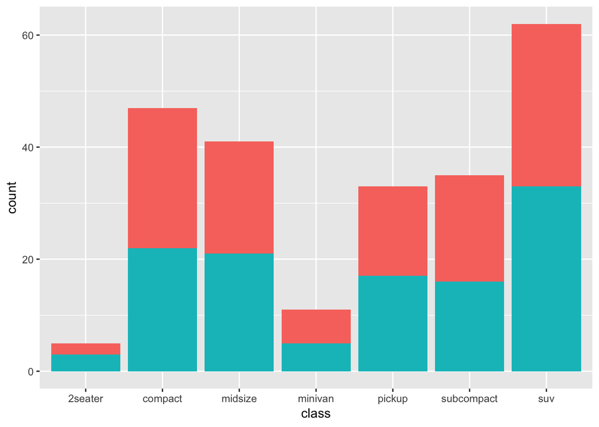

### 2.2 隐藏图例标题

- 方法1: `guides(fill=guide_legend(title=NULL)`，把fill产生的图例的标题去掉，同理可以去掉color,shape的图例标题
- 方法2： `theme(legend.title=element_blank())`

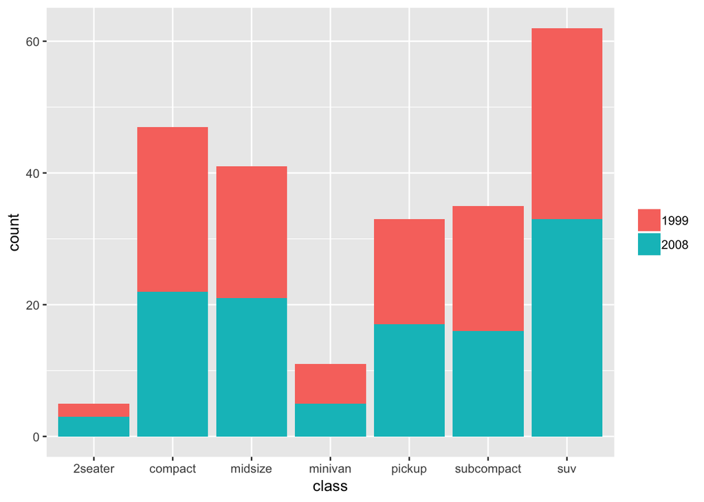

```r
library(ggplot2)
p <- ggplot(mpg, aes(x=class, fill=factor(year)))
# p + geom_bar() + guides(fill = guide_legend(title = NULL)) #方法1
p + geom_bar() + theme(legend.title = element_blank())
```

### 2.3 调整图例顺序

用 `scale_color_discrete`，通过 `breaks` 参数设置图例的顺序（注意也可以把fill改成`fill`或者`shape`).

注意设置`breaks`时，图例的名称必须和原图例的名称相同，否则会出现图例名称不显示的情况。

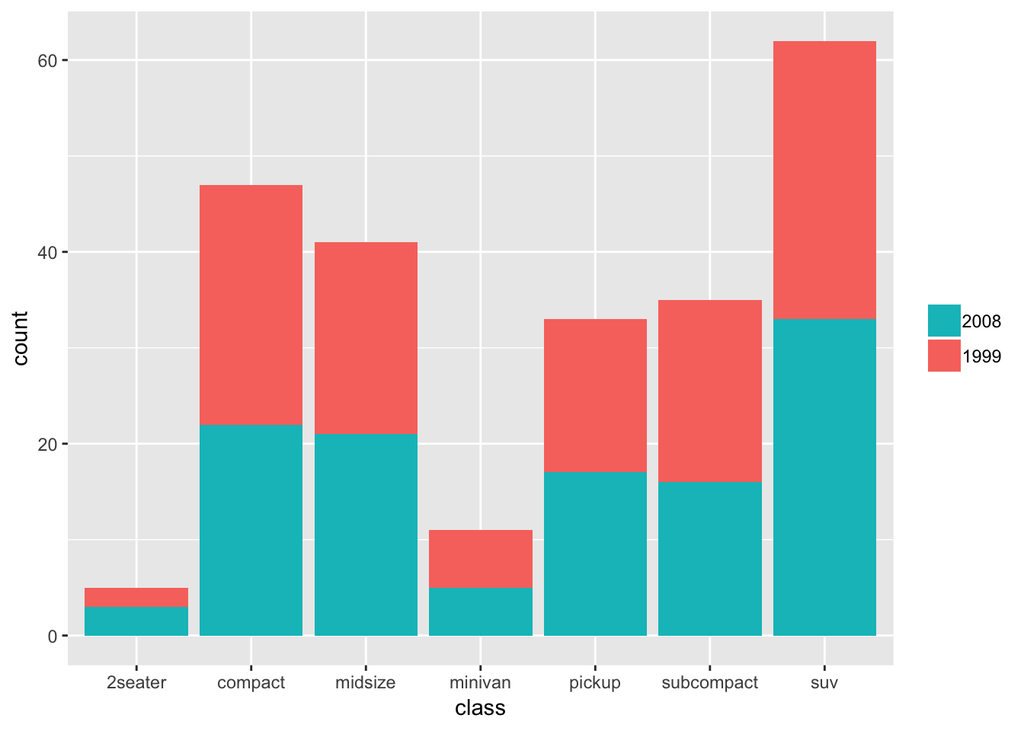

```r
library(ggplot2)
p <- ggplot(mpg, aes(x=class, fill=factor(year)))
p + geom_bar() + theme(legend.title = element_blank()) + scale_fill_discrete(breaks = c('2008', '1999'))
```

### 2.4 修改图例标签文字

用 `scale_color_discrete`，通过 `breaks` 和`labels` 参数共同设置图例的新标签。

注意设置`breaks`时，图例的名称必须和原图例的名称相同，否则会出现图例名称不显示的情况。

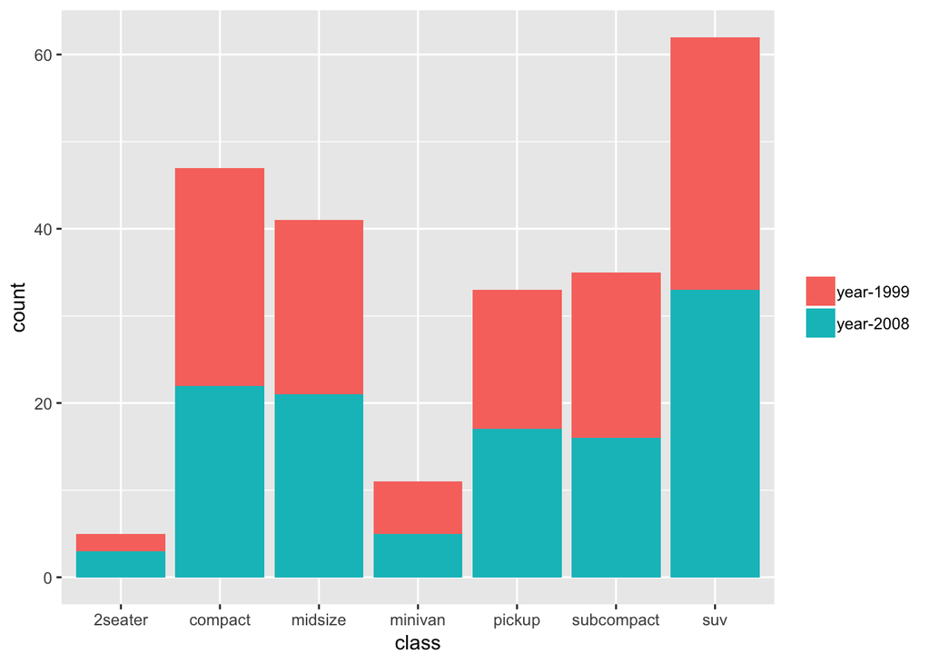

```r
library(ggplot2)
p <- ggplot(mpg, aes(x=class, fill=factor(year)))
p + geom_bar() + theme(legend.title = element_blank()) + scale_fill_discrete(breaks = c('1999', '2008'), labels = c('year-1999','year-2008'))
```

### 2.5 调整图例大小、颜色

`theme(legend.text = element_text(size,color))`

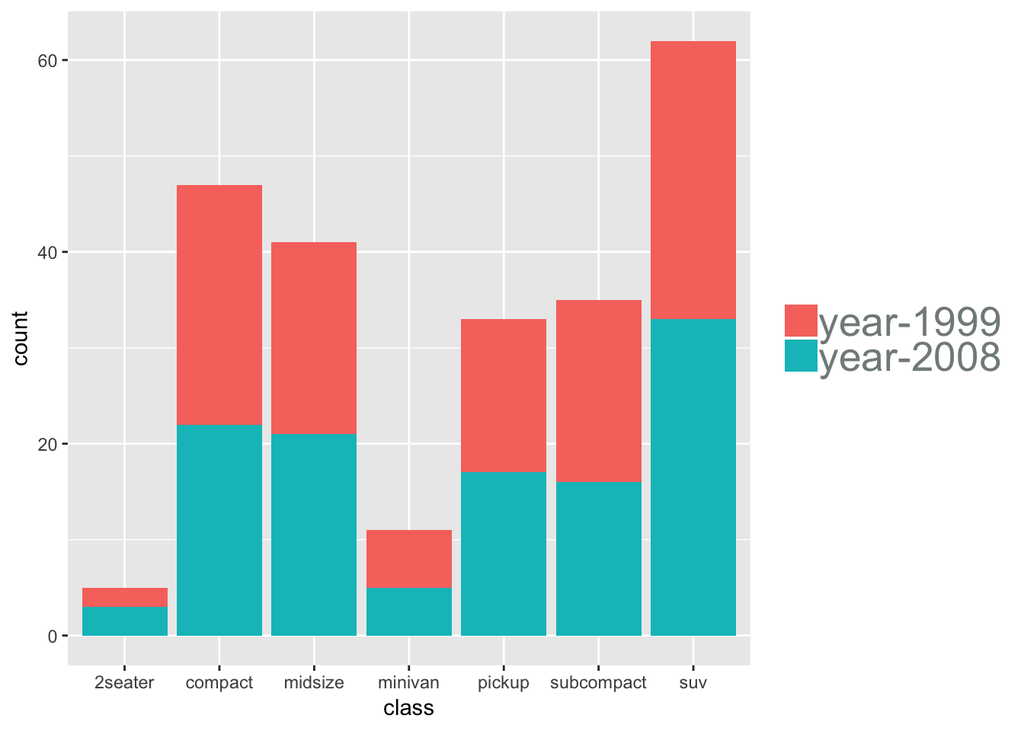

```r
library(ggplot2)
p <- ggplot(mpg, aes(x=class, fill=factor(year)))
p + geom_bar() + theme(legend.title = element_blank()) + scale_fill_discrete(breaks = c('1999', '2008'), labels = c('year-1999','year-2008')) + theme(legend.text = element_text(size = 20, color ="azure4"))
```

### 2.6 修改图例位置

`theme(legend.position = 'top')`,把图例放置在图片上方。同理还有 bottom, left, right。

另外，形如`legend.position = c(0.2,0.8)`的方式可以把图例放入到图片内。

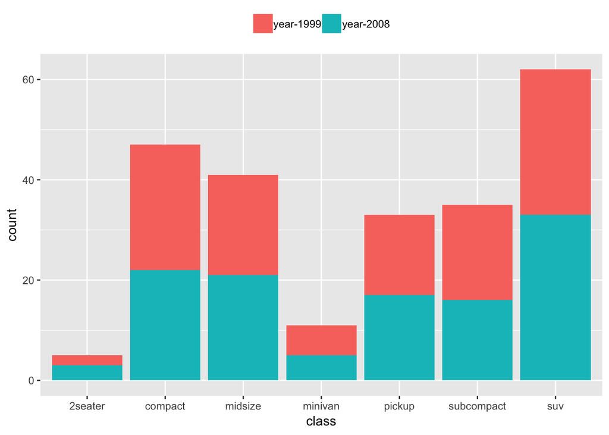

```r
library(ggplot2)
p <- ggplot(mpg, aes(x=class, fill=factor(year)))
p + geom_bar() + theme(legend.title = element_blank()) + scale_fill_discrete(breaks = c('1999', '2008'), labels = c('year-1999','year-2008')) + theme(legend.position = 'top')
```

### 2.7 其他

- `legend.direction = 'horizontal' or 'vertical'`: 设置图例是水平还是垂直放置
- 调整图例key的大小： `theme(legend.key.size = unit(1, 'cm'))`
- 调整图例之间的间隙： `them(legend.spacing.x, legend.x.spacing.y)`

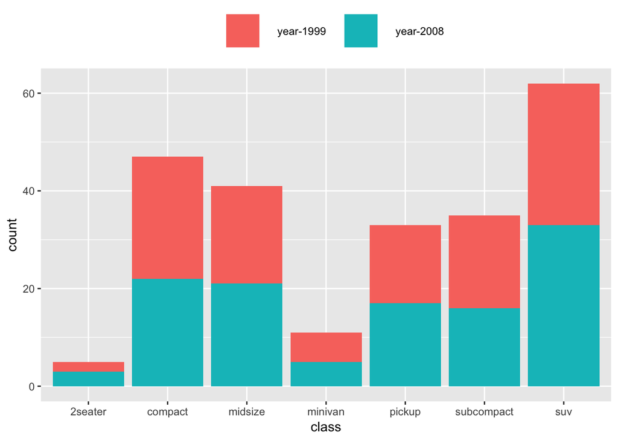

```r
library(ggplot2)
p <- ggplot(mpg, aes(x=class, fill=factor(year)))
p + geom_bar() + theme(legend.title = element_blank()) + scale_fill_discrete(breaks = c('1999', '2008'), labels = c('year-1999','year-2008')) + theme(legend.position = 'top', legend.spacing.x = unit(0.5,'cm'),legend.key.size = unit(1, 'cm'), legend.direction = 'horizontal')
```